# 140.653 Lab 2: Cross validation

Erjia Cui & Elizabeth Colantuoni

## Scenario 1. Without using Cross Validation

The dataset we used today is the **diamonds** dataset in ggplot2 package. This dataset contains the prices and other attributes of almost 54,000 diamonds. The variables are as follows:

- **price**: price in US dollars ($326–$18,823)
- **carat**: weight of the diamond (0.2–5.01)

For illustration purpose, we extract a subset of 300 samples

```r
# load packages
library(ggplot2)
library(splines)
```

```r
# subsample diamond dataset
set.seed(123) # random number generation for reproducibility
subdiamond <- diamonds[sample(1:nrow(diamonds), 300, replace = F),]
saveRDS(subdiamond,'./lab2_data.rds') # save a variable into RDS file
```

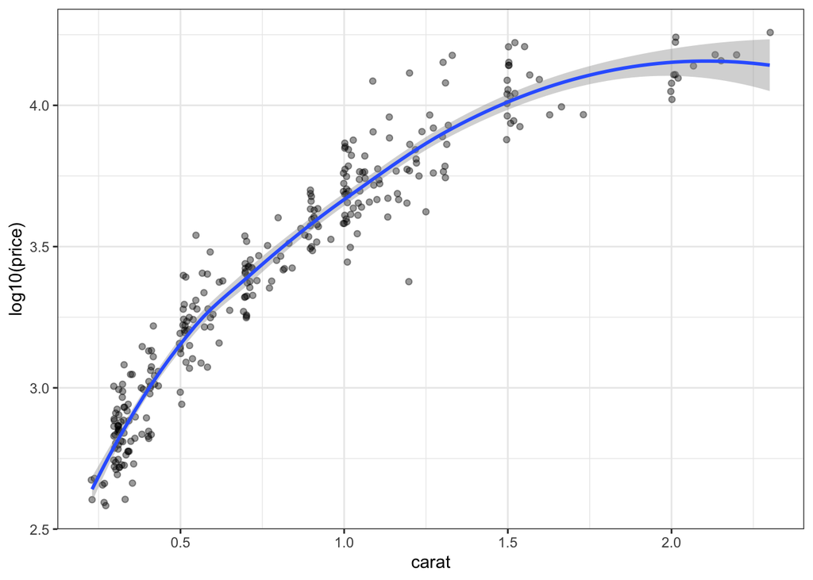

```r
# read in dataset
subdiamond <- readRDS('./lab2_data.rds')
# plot log 10 price of diamonds against carat
ggplot(subdiamond, aes(carat, log10(price))) +
  theme_bw() +
  geom_jitter(alpha = 0.4) +
  geom_smooth()
```

```r
# create variable logprice, a log transformed price
subdiamond$logprice <- log10(subdiamond$price)

# 1. simple linear regression
lmfit <- lm(logprice ~ carat, subdiamond)
summary(lmfit)
```

```
##
## Call:
## lm(formula = logprice ~ carat, data = subdiamond)
##
## Residuals:
##      Min       1Q   Median       3Q      Max
## -0.45709 -0.09231  0.01975  0.11182  0.43917
##
## Coefficients:
##             Estimate Std. Error t value Pr(>|t|)
## (Intercept)  2.68431    0.01912   140.4   <2e-16 ***
## carat        0.88289    0.02039    43.3   <2e-16 ***
## ---
## Signif. codes:  0 '***' 0.001 '**' 0.01 '*' 0.05 '.' 0.1 ' ' 1
##
## Residual standard error: 0.1632 on 298 degrees of freedom
## Multiple R-squared:  0.8628, Adjusted R-squared:  0.8624
## F-statistic:  1875 on 1 and 298 DF,  p-value: < 2.2e-16
```

```r
# 2. natural spline with 3 degrees of freedom
nsfit <- lm(logprice ~ ns(carat, 3), subdiamond)
summary(nsfit)
```

```
##
## Call:
## lm(formula = logprice ~ ns(carat, 3), data = subdiamond)
##
## Residuals:
##      Min       1Q   Median       3Q      Max
## -0.44810 -0.08121 -0.00200  0.06696  0.33511
##
## Coefficients:
##               Estimate Std. Error t value Pr(>|t|)
## (Intercept)    2.68403    0.01913  140.27   <2e-16 ***
## ns(carat, 3)1  1.07969    0.03048   35.42   <2e-16 ***
## ns(carat, 3)2  1.96657    0.05054   38.91   <2e-16 ***
## ns(carat, 3)3  1.23819    0.03953   31.32   <2e-16 ***
## ---
## Signif. codes:  0 '***' 0.001 '**' 0.01 '*' 0.05 '.' 0.1 ' ' 1
##
## Residual standard error: 0.1099 on 296 degrees of freedom
## Multiple R-squared:  0.9382, Adjusted R-squared:  0.9375
## F-statistic:  1497 on 3 and 296 DF,  p-value: < 2.2e-16
```

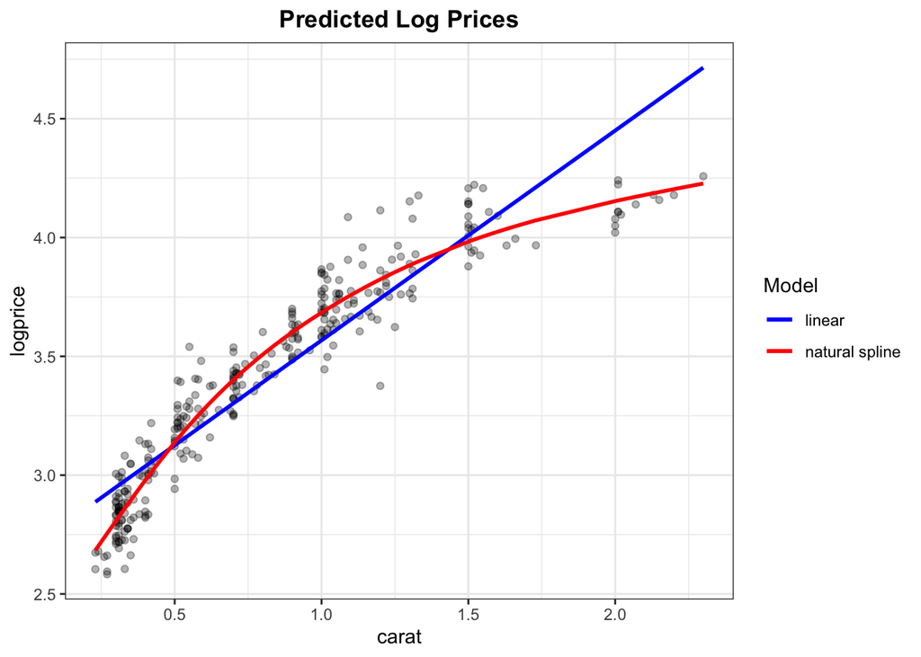

```r
# plot fitted line & curve
subdiamond$lmfit <- predict(lmfit)
subdiamond$nsfit <- predict(nsfit)

ggplot(subdiamond) +
  theme_bw() +
  geom_point(aes(carat, logprice), alpha = 0.3) +
  geom_line(aes(carat, lmfit, col = "c1"), size = 1) +
  geom_line(aes(carat, nsfit, col = "c2"), size = 1) +
  scale_colour_manual(name = 'Model', values = c('c1' = 'blue', 'c2' = 'red'),
                      labels = c('linear', 'natural spline')) +
  ggtitle("Predicted Log Prices") +
  theme(plot.title = element_text(hjust = 0.5, face = "bold"))
```

Question: What can you observe from this figure? Which model performs better and why?

```r
# non-CV prediction error (MSE)
mean((subdiamond$logprice - subdiamond$lmfit)^2)
```

```
## [1] 0.02644275
```

```r
mean((subdiamond$logprice - subdiamond$nsfit)^2)
```

```
## [1] 0.01192268
```

## Scenario 2. 10-fold Cross Validation (CV)

Suppose we would like to compare the following two models and select a better model with higher prediction accuracy:

- **Model 1**: plain model (use carat as the only linear predictor)
- **Model 2**: natural spline model (using ns(carat,3) as predictor)

Key steps:

1. How to implement the above models in R?
2. 10-fold CV procedure
3. How to store predicted values from two different models?

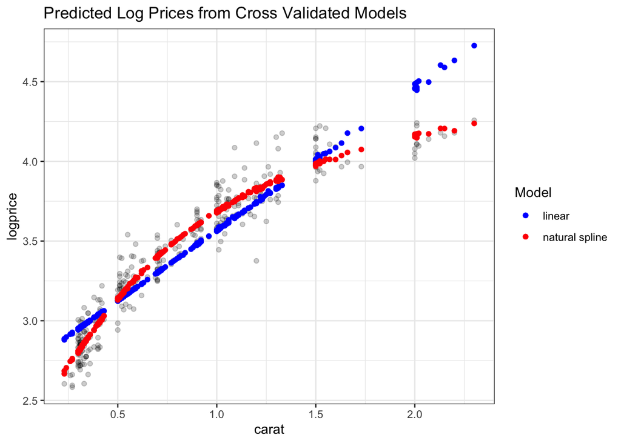

```r
# randomly split the observations into 10 categories
rows <- 1:nrow(subdiamond)

set.seed(123)
shuffled.rows <- sample(rows, replace = FALSE) ## shuffle the rows

B <- 10 # Number of folds

# divide the rows into 10 intervals and codes each row according to which interval they fall
folds <- cut(rows, breaks = B, labels=FALSE)

# create a dataset with predicted log price from cross validation
pred.data <- NULL

# do cross validation
for (i in 1:B){

    # divide data into test set (1/10) and training set (9/10)
    test.rows <- shuffled.rows[which(folds == i)]
    train.rows <-  shuffled.rows[which(folds != i)]

    test.data <- subdiamond[test.rows, ]
    train.data <- subdiamond[train.rows, ]

    # fit two models and obtain predicted value
    fit <- lm(logprice ~ carat, train.data)
    test.data$predicted.lm <- predict(fit, newdata = test.data[, "carat"])

    fitns <- lm(logprice ~ ns(carat, 3), train.data)
    test.data$predicted.ns <- predict(fitns, newdata = test.data[, "carat"])

    # stack and store new predicted data
    pred.data <- rbind(pred.data, test.data)

}


# Plot predicted log prices from CV
ggplot(pred.data) +
  theme_bw() +
  geom_point(aes(carat, logprice), alpha = 0.2) +
  geom_point(aes(carat, predicted.lm, col = "c1")) +
  geom_point(aes(carat, predicted.ns, col = "c2")) +
  scale_colour_manual(name = 'Model', values = c('c1' = 'blue','c2' = 'red'),
                      labels = c('linear', 'natural spline')) +
  ggtitle("Predicted Log Prices from Cross Validated Models")
```

```r
# cross-validated prediction error
mean((pred.data$logprice - pred.data$predicted.lm)^2)
```

```
## [1] 0.02698985
```

```r
mean((pred.data$logprice - pred.data$predicted.ns)^2)
```

```
## [1] 0.01235098
```

**Conclusion**

In 10-fold cross validation, we observed that Model 2: natural spline with 3 degrees of freedom has lower Mean Squared Error and thus Model 2 performs better than Model 1 .

**Question**

How would non-CV and CV prediction error change as you increase the degree of freedom in natural spline model?

## 3. In class exercise: Using **nepal.anthro** dataset

This dataset contains anthropologic measurements on Nepalease children. There are 1000 records in total but here we subsampled 500 samples. (please use ‘lab2_exercise.rds’ dataset for this exercise). Some key variables are:

- age: Age of child in months
- gender: Gender is coded: 1 = male; 2 = female.
- weight: Child’s weight measured in kilograms.
- height: Child’s height measured in centimeters.
- arm circumference: Child’s mid upper arm circumference measured in centimeters.

Suppose we would like to find the ‘best’ degrees of freedom in natural spline model (with highest prediction accuracy):

- Model natural spline model, only using age as predictor (i.e. ns(age,df))

Tasks:

- 1. To identify the ideal degrees of freedom for the smooth relationship between average arm circumference and age in the Nepal dataset (i.e. degrees of freedom range: 1-7)
- 2. Make a publication-quality figure and describe what you observed.